# DS202_lab4

Kyle Schallau

10/22/2021

# Loading the data

```r
library(dplyr)
library(tidyverse)
```

```r
library(readxl)
defense <- read_excel('../DS202_lab4/cyclonesFootball2020.xlsx', sheet='Defensive')
offense <- read_excel('../DS202_lab4/cyclonesFootball2020.xlsx', sheet='Offensive')
biography <- read_excel('../DS202_lab4/cyclonesFootball2020.xlsx', sheet='Biography')
```

# Joining and Tidying ISU Football Data

# Part one: Cleaning data

Although the three Excel sheets are loaded into R, they are not useful before some cleaning. Manipulate the three imported data frames:

1. The player names and opponent names should be factors.

```r
defense$Name <- as.factor(defense$Name)
defense$Opponent_Opponent <- as.factor(defense$Opponent_Opponent)
str(defense)
```

```
## tibble [372 x 11] (S3: tbl_df/tbl/data.frame)
##  $ Name             : Factor w/ 37 levels "Akers, Landen",..: 26 26 26 26 26 26 26 26 26 26 ...
##  $ Opponent_Opponent: Factor w/ 11 levels "Baylor","Kansas",..: 4 8 5 10 6 2 1 3 9 11 ...
##  $ Tackles_Solo     : chr [1:372] "2" "6" "6" "3" ...
##  $ Tackles_ASST     : chr [1:372] "4" "4" "5" "0" ...
##  $ Tackles_TFL      : chr [1:372] "1.0" "0" "1.5" "1.0" ...
##  $ Tackles_Sack     : chr [1:372] "0" "0" "0.5" "0" ...
##  $ Turnover_FF      : chr [1:372] "0" "0" "0" "0" ...
##  $ Turnover_FR      : chr [1:372] "0" "0" "0" "0" ...
##  $ Turnover_INT     : chr [1:372] "0" "1" "0" "0" ...
##  $ Pass_QBH         : chr [1:372] "0" "0" "1" "0" ...
##  $ Pass_PB          : chr [1:372] "0" "0" "0" "0" ...
```

```r
offense$Name <- as.factor(offense$Name)
offense$Opponent_Opponent <- as.factor(offense$Opponent_Opponent)
str(offense)
```

```
## tibble [156 x 12] (S3: tbl_df/tbl/data.frame)
##  $ Name             : Factor w/ 16 levels "Akers, Landen",..: 1 1 1 1 1 1 1 1 1 1 ...
##  $ Opponent_Opponent: Factor w/ 11 levels "Baylor","Kansas",..: 4 8 5 10 6 2 1 3 9 11 ...
##  $ Receiving_REC    : chr [1:156] "0" "2" "1" "4" ...
##  $ Receiving_YDS    : chr [1:156] "0" "60" "35" "34" ...
##  $ Receiving_TD     : chr [1:156] "0" "0" "0" "0" ...
##  $ Rushing_ATT      : chr [1:156] NA NA NA NA ...
##  $ Rushing_YDS      : chr [1:156] NA NA NA NA ...
##  $ Rushing_TD       : chr [1:156] NA NA NA NA ...
##  $ Passing_CMP-ATT  : chr [1:156] NA NA NA NA ...
##  $ Passing_YDS      : chr [1:156] NA NA NA NA ...
##  $ Passing_TD       : chr [1:156] NA NA NA NA ...
##  $ Passing_INT      : chr [1:156] NA NA NA NA ...
```

```r
biography$Name <- as.factor(biography$Name)
str(biography)
```

```
## tibble [116 x 7] (S3: tbl_df/tbl/data.frame)
##  $ Name      : Factor w/ 116 levels "Akers, Landen",..: 1 2 3 4 5 6 7 8 9 10 ...
##  $ Position  : chr [1:116] "Wide Receiver" "Tight End" "Wide Receiver" "Defensive Back" ...
##  $ Height    : chr [1:116] "6-0" "6-7" "6-5" "6-0" ...
##  $ Weight    : chr [1:116] "191" "240" "208" "180" ...
##  $ Class     : chr [1:116] "Redshirt Senior" "Redshirt Senior" "Redshirt Freshman" "Freshman" ...
##  $ Hometown  : chr [1:116] "Cedar Rapids, Iowa" "Nixa, Mo." "Seffner, Fla." "Ft. Lauderdale, Fla." ...
##  $ Highschool: chr [1:116] "Washington" "Nixa" "Armwood" "Cardinal Gibbons" ...
```

2. All offensive and defensive statistics should be numerical. The Weight column in biography should also be numeric. (Optional: Read ?across and learn to mutate multiple columns simultaneously using the across function in dplyr)

```r
offClean <- offense %>%
  mutate(across(Receiving_REC:Passing_INT, as.numeric))
str(offClean)
```

```
## tibble [156 x 12] (S3: tbl_df/tbl/data.frame)
##  $ Name             : Factor w/ 16 levels "Akers, Landen",..: 1 1 1 1 1 1 1 1 1 1 ...
##  $ Opponent_Opponent: Factor w/ 11 levels "Baylor","Kansas",..: 4 8 5 10 6 2 1 3 9 11 ...
##  $ Receiving_REC    : num [1:156] 0 2 1 4 0 6 1 0 1 1 ...
##  $ Receiving_YDS    : num [1:156] 0 60 35 34 0 76 11 0 10 2 ...
##  $ Receiving_TD     : num [1:156] 0 0 0 0 0 0 0 0 0 1 ...
##  $ Rushing_ATT      : num [1:156] NA NA NA NA NA NA NA NA NA NA ...
##  $ Rushing_YDS      : num [1:156] NA NA NA NA NA NA NA NA NA NA ...
##  $ Rushing_TD       : num [1:156] NA NA NA NA NA NA NA NA NA NA ...
##  $ Passing_CMP-ATT  : num [1:156] NA NA NA NA NA NA NA NA NA NA ...
##  $ Passing_YDS      : num [1:156] NA NA NA NA NA NA NA NA NA NA ...
##  $ Passing_TD       : num [1:156] NA NA NA NA NA NA NA NA NA NA ...
##  $ Passing_INT      : num [1:156] NA NA NA NA NA NA NA NA NA NA ...
```

```r
defClean <- defense %>%
  mutate(across(Tackles_Solo:Pass_PB, as.numeric))
str(defClean)
```

```
## tibble [372 x 11] (S3: tbl_df/tbl/data.frame)
##  $ Name             : Factor w/ 37 levels "Akers, Landen",..: 26 26 26 26 26 26 26 26 26 26 ...
##  $ Opponent_Opponent: Factor w/ 11 levels "Baylor","Kansas",..: 4 8 5 10 6 2 1 3 9 11 ...
##  $ Tackles_Solo     : num [1:372] 2 6 6 3 7 4 7 4 4 2 ...
##  $ Tackles_ASST     : num [1:372] 4 4 5 0 3 1 4 3 9 3 ...
##  $ Tackles_TFL      : num [1:372] 1 0 1.5 1 1 0 1.5 2.5 1.5 0 ...
##  $ Tackles_Sack     : num [1:372] 0 0 0.5 0 0 0 0 1 0 0 ...
##  $ Turnover_FF      : num [1:372] 0 0 0 0 0 0 0 0 0 0 ...
##  $ Turnover_FR      : num [1:372] 0 0 0 0 0 0 0 0 0 0 ...
##  $ Turnover_INT     : num [1:372] 0 1 0 0 1 0 1 1 0 0 ...
##  $ Pass_QBH         : num [1:372] 0 0 1 0 0 0 2 1 0 0 ...
##  $ Pass_PB          : num [1:372] 0 0 0 0 0 1 0 0 1 0 ...
```

```r
bioClean <- biography %>%
  mutate(across(Weight, as.numeric))
str(bioClean)
```

```
## tibble [116 x 7] (S3: tbl_df/tbl/data.frame)
##  $ Name      : Factor w/ 116 levels "Akers, Landen",..: 1 2 3 4 5 6 7 8 9 10 ...
##  $ Position  : chr [1:116] "Wide Receiver" "Tight End" "Wide Receiver" "Defensive Back" ...
##  $ Height    : chr [1:116] "6-0" "6-7" "6-5" "6-0" ...
##  $ Weight    : num [1:116] 191 240 208 180 195 199 253 261 288 182 ...
##  $ Class     : chr [1:116] "Redshirt Senior" "Redshirt Senior" "Redshirt Freshman" "Freshman" ...
##  $ Hometown  : chr [1:116] "Cedar Rapids, Iowa" "Nixa, Mo." "Seffner, Fla." "Ft. Lauderdale, Fla." ...
##  $ Highschool: chr [1:116] "Washington" "Nixa" "Armwood" "Cardinal Gibbons" ...
```

3. The Height column in biography should be numeric. (Hint: Use a unit that works well)

```r
bioClean <- bioClean %>%
  separate(Height, c('Feet','Height_Inches'), sep = '-', convert = TRUE, remove = FALSE) %>%
  mutate(Height_Inches = 12*Feet + Height_Inches)
bioClean <- subset(bioClean, select = -c(Height, Feet) )
str(bioClean)
```

```
## tibble [116 x 7] (S3: tbl_df/tbl/data.frame)
##  $ Name         : Factor w/ 116 levels "Akers, Landen",..: 1 2 3 4 5 6 7 8 9 10 ...
##  $ Position     : chr [1:116] "Wide Receiver" "Tight End" "Wide Receiver" "Defensive Back" ...
##  $ Height_Inches: num [1:116] 72 79 77 72 72 72 75 74 74 74 ...
##  $ Weight       : num [1:116] 191 240 208 180 195 199 253 261 288 182 ...
##  $ Class        : chr [1:116] "Redshirt Senior" "Redshirt Senior" "Redshirt Freshman" "Freshman" ...
##  $ Hometown     : chr [1:116] "Cedar Rapids, Iowa" "Nixa, Mo." "Seffner, Fla." "Ft. Lauderdale, Fla." ...
##  $ Highschool   : chr [1:116] "Washington" "Nixa" "Armwood" "Cardinal Gibbons" ...
```

4. Add a column to both defense and offense indicating whether it is the first or the second game versus an opponent. We had a single game versus each opponent except for Oklahoma, which we played against twice. (Hint: You can use group_by(), mutate(), and row_number())

```r
offClean <- offClean %>%
  group_by(Name, Opponent_Opponent) %>%
  mutate(Game = row_number())

offClean %>%
  select(Name, Opponent_Opponent, Game)
```

```
## # A tibble: 156 x 3
## # Groups:   Name, Opponent_Opponent [143]
##    Name          Opponent_Opponent  Game
##    <fct>         <fct>             <int>
##  1 Akers, Landen Louisiana             1
##  2 Akers, Landen TCU                   1
##  3 Akers, Landen Oklahoma              1
##  4 Akers, Landen Texas Tech            1
##  5 Akers, Landen Oklahoma St.          1
##  6 Akers, Landen Kansas                1
##  7 Akers, Landen Baylor                1
##  8 Akers, Landen Kansas State          1
##  9 Akers, Landen Texas                 1
## 10 Akers, Landen West Virginia         1
## # ... with 146 more rows
```

```r
defClean <- defClean %>%
  group_by(Name, Opponent_Opponent) %>%
  mutate(Game = row_number())

defClean %>%
  select(Name, Opponent_Opponent, Game)
```

```
## # A tibble: 372 x 3
## # Groups:   Name, Opponent_Opponent [344]
##    Name       Opponent_Opponent  Game
##    <fct>      <fct>             <int>
##  1 Rose, Mike Louisiana             1
##  2 Rose, Mike TCU                   1
##  3 Rose, Mike Oklahoma              1
##  4 Rose, Mike Texas Tech            1
##  5 Rose, Mike Oklahoma St.          1
##  6 Rose, Mike Kansas                1
##  7 Rose, Mike Baylor                1
##  8 Rose, Mike Kansas State          1
##  9 Rose, Mike Texas                 1
## 10 Rose, Mike West Virginia         1
## # ... with 362 more rows
```

# Part two: Tidying and exploring

For the following questions, work on the cleaned data frames defClean, offClean, and bioClean.

1. Reformat the offClean data frame into a tidy format using pivot_longer. The type of statistic (Receiving_REC for the number of receivings, Receiving_YDS for receiving yards, etc) is added as a new key column named stat.

```r
offClean <- offClean %>%
  pivot_longer(Receiving_REC:Passing_INT, names_to = 'Stat',  values_to = 'Total')
offClean
```

```
## # A tibble: 1,560 x 5
## # Groups:   Name, Opponent_Opponent [143]
##    Name          Opponent_Opponent  Game Stat            Total
##    <fct>         <fct>             <int> <chr>           <dbl>
##  1 Akers, Landen Louisiana             1 Receiving_REC       0
##  2 Akers, Landen Louisiana             1 Receiving_YDS       0
##  3 Akers, Landen Louisiana             1 Receiving_TD        0
##  4 Akers, Landen Louisiana             1 Rushing_ATT        NA
##  5 Akers, Landen Louisiana             1 Rushing_YDS        NA
##  6 Akers, Landen Louisiana             1 Rushing_TD         NA
##  7 Akers, Landen Louisiana             1 Passing_CMP-ATT    NA
##  8 Akers, Landen Louisiana             1 Passing_YDS        NA
##  9 Akers, Landen Louisiana             1 Passing_TD         NA
## 10 Akers, Landen Louisiana             1 Passing_INT        NA
## # ... with 1,550 more rows
```

2. Obtain the player-level offensive statistics. Namely, for each player and each type of statistics, obtain the sum of the statistics in all games.

```r
offClean <- drop_na(offClean)

offClean %>%
  group_by(Name, Stat) %>%
  summarize(sum(Total))
```

```
## # A tibble: 66 x 3
## # Groups:   Name [16]
##    Name          Stat          `sum(Total)`
##    <fct>         <chr>                <dbl>
##  1 Akers, Landen Receiving_REC           18
##  2 Akers, Landen Receiving_TD             1
##  3 Akers, Landen Receiving_YDS          269
##  4 Allen, Chase  Receiving_REC           19
##  5 Allen, Chase  Receiving_TD             2
##  6 Allen, Chase  Receiving_YDS          236
##  7 Bitter, Aidan Receiving_REC            1
##  8 Bitter, Aidan Receiving_TD             0
##  9 Bitter, Aidan Receiving_YDS           38
## 10 Brock, Jirehl Receiving_REC            4
## # ... with 56 more rows
```

3. Show the distributions of the player-level offensive statistics. The distribution of each offensive statistic should be shown in a separate facet. Explain the patterns you see.

Based on the below graphs, 0 was the highest in each category. There was a large number of the players who achieved little to none of the below stats. As the stat number increased, the number of players who achieved higher in that stat went down significantly. There are a few players that have very large stats.

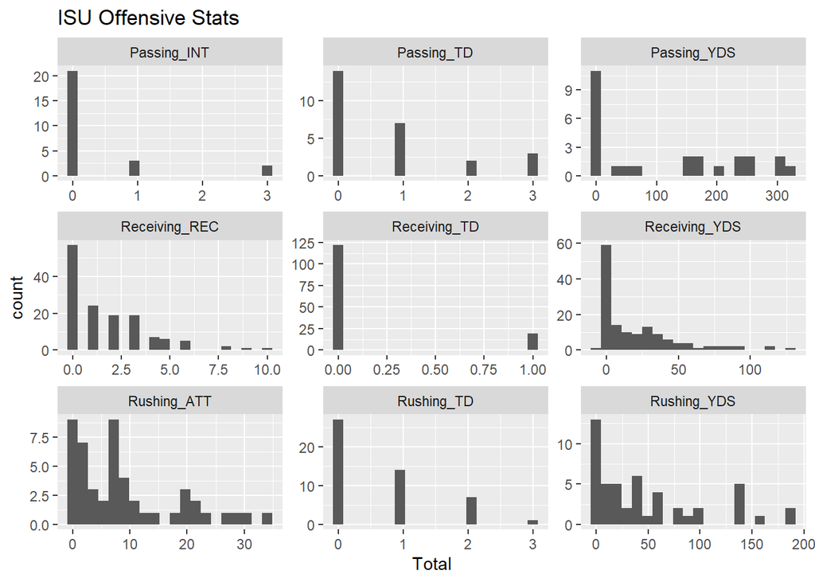

```r
ggplot(offClean, aes(x = Total)) + geom_histogram(bins = 20) + facet_wrap(~ Stat, scales = 'free') + ggtitle("ISU Offensive Stats")
```

4. Did ISU have better offense against Oregon or Oklahoma? Answer this question by creating a scatterplot with the x- and y-axes being the receiving yards of the ISU players against each of these two opponents.

Based on the below graph, ISU had better offense against Oklahoma. There are more points that fall along the right side of the graph.

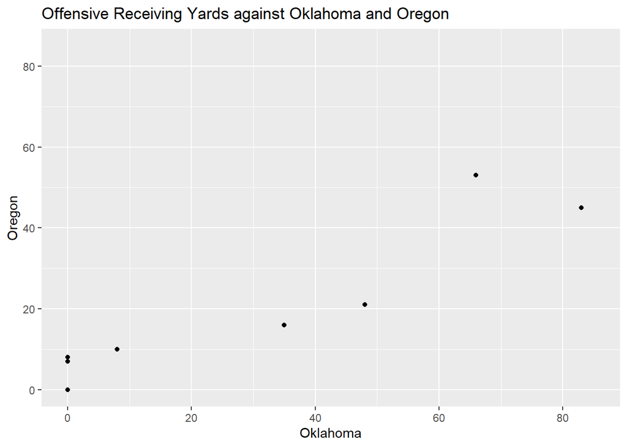

```r
offClean1 <- offClean %>%
  filter(Stat == "Receiving_YDS" & (Opponent_Opponent == "Oregon" | Opponent_Opponent == "Oklahoma")) %>%
  pivot_wider(names_from = 'Opponent_Opponent', values_from = "Total", values_fn = mean)

ggplot(offClean1, aes(x = Oklahoma, y = Oregon)) + geom_point() + ggtitle("Offensive Receiving Yards against Oklahoma and Oregon") + xlim(0,85) + ylim(0,85)
```

Now turn our attention to the player biography.

4 Separate the Hometown column into two columns, namely, the city and the state where the player comes from. Print the first few rows of these two columns. (Hint: look at the sep= argument of separate)

```r
bioClean <- bioClean %>%
  separate(Hometown, c('City', 'State'), sep=', ')
head(bioClean[6:7], 10)
```

```
## # A tibble: 10 x 2
##    City           State
##    <chr>          <chr>
##  1 Cedar Rapids   Iowa
##  2 Nixa           Mo.
##  3 Seffner        Fla.
##  4 Ft. Lauderdale Fla.
##  5 Naperville     Ill.
##  6 Grand Prairie  Texas
##  7 Clarksdale     Miss.
##  8 Jacksonville   Fla.
##  9 Jacksonville   Fla.
## 10 Tampa          Fla.
```

5. How many players are there from each state?

```r
bioClean$State <- as.factor(bioClean$State)
summary(bioClean$State)
```

```
##     Ariz.      Ark. Australia    Calif.      Fla.       Ga.      Ill.      Iowa
##         4         1         1         2        14         3         6        42
##      Kan.      Mich     Mich.     Minn.     Miss.       Mo.      Neb.      Ohio
##         4         1         2         8         1         5         1         6
##     Okla.       Pa.      S.D.     Texas      Wis.
##         2         1         2         7         3
```

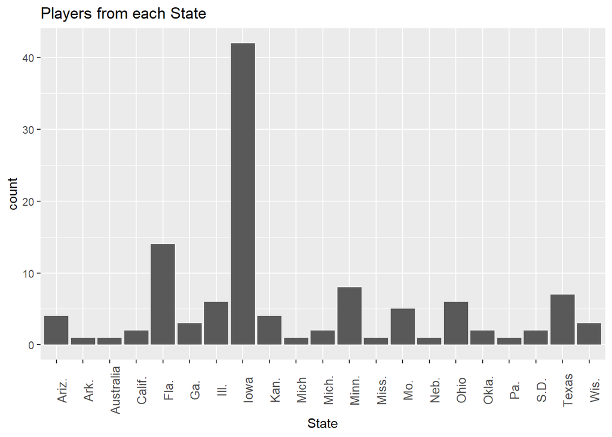

```r
ggplot(bioClean, aes(x=State)) + geom_bar() + ggtitle("Players from each State") + theme(axis.text.x = element_text(angle = 90, size = 10))
```

6. How does the performance of quarterback Brock Purdy relate to the performance of the ISU team? Comment on both the defense and offense.

Based on the below offense performance histograms, Brock Purdy is very good at offense. He has some impressive stats in some categories. For one, he has had a few games where he passed for around 300 yards, which is good. There are also a few games in which he has around three passing TDs each game. Purdy is also pretty good on his feet. He has picked up around 50 yards rushing for a few games. Overall, Purdy does way better on the offense than the defense compared to other players and he is the best at passing than any other player.

```r
defClean <- defClean %>%
  pivot_longer(Tackles_Solo:Pass_PB, names_to = 'Stat',  values_to = 'Total')
defClean
```

```
## # A tibble: 3,348 x 5
## # Groups:   Name, Opponent_Opponent [344]
##    Name       Opponent_Opponent  Game Stat         Total
##    <fct>      <fct>             <int> <chr>        <dbl>
##  1 Rose, Mike Louisiana             1 Tackles_Solo     2
##  2 Rose, Mike Louisiana             1 Tackles_ASST     4
##  3 Rose, Mike Louisiana             1 Tackles_TFL      1
##  4 Rose, Mike Louisiana             1 Tackles_Sack     0
##  5 Rose, Mike Louisiana             1 Turnover_FF      0
##  6 Rose, Mike Louisiana             1 Turnover_FR      0
##  7 Rose, Mike Louisiana             1 Turnover_INT     0
##  8 Rose, Mike Louisiana             1 Pass_QBH         0
##  9 Rose, Mike Louisiana             1 Pass_PB          0
## 10 Rose, Mike TCU                   1 Tackles_Solo     6
## # ... with 3,338 more rows
```

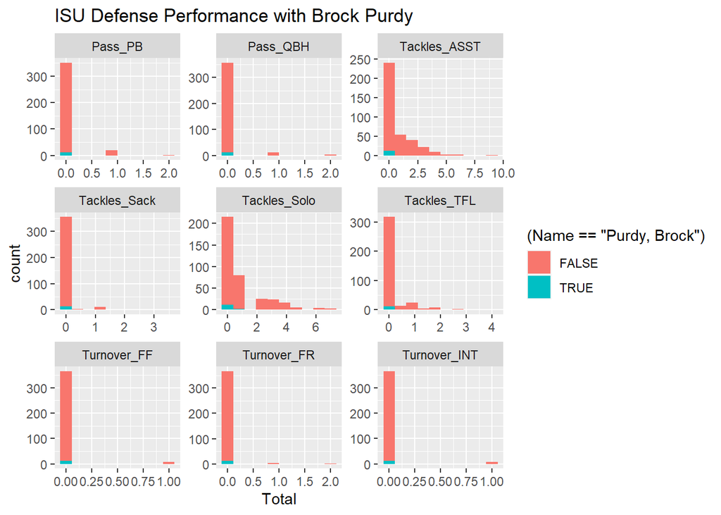

```r
ggplot(defClean, aes(x = Total, fill = (Name == "Purdy, Brock"))) + geom_histogram(bins = 10) + facet_wrap(~ Stat, scales = 'free') + ggtitle("ISU Defense Performance with Brock Purdy")
```

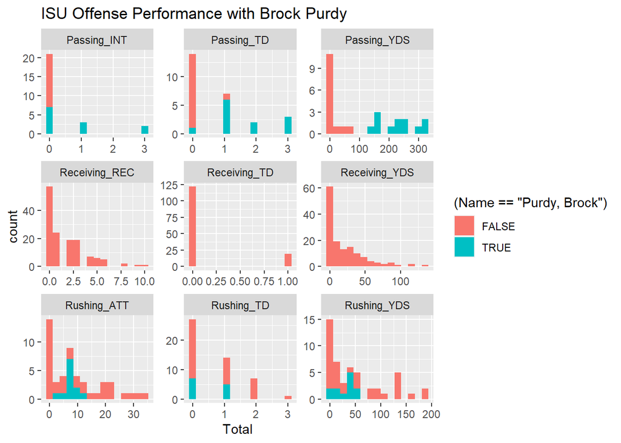

```r
ggplot(offClean, aes(x = Total, fill = (Name == "Purdy, Brock"))) + geom_histogram(bins = 15) + facet_wrap(~ Stat, scales = 'free') + ggtitle("ISU Offense Performance with Brock Purdy")
```